# Steinhart_Titanic

2020-09-15

```r
titanic <- read.csv("~/Desktop/Steinhart_Project_01./Data Raw/titanic.csv")
```

# Titanic Class

```r
table(titanic$Class)
```

```
##
##  1st  2nd  3rd Crew
##  325  285  706  885
```

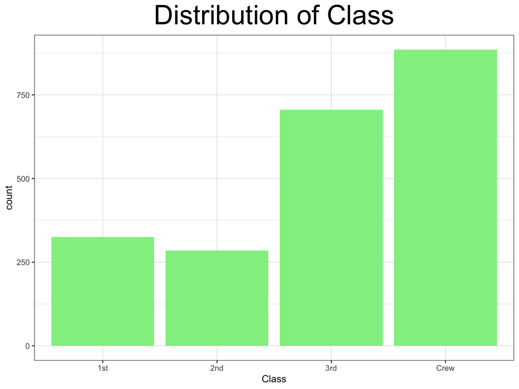

```r
ggplot(data = titanic) + geom_bar(mapping = aes(x = Class), fill="lightgreen") +ggtitle("Distribution of Class") + theme(plot.title= element_text(size=30)) + theme(plot.title = element_text(hjust = 0.5))
```

- The Researcher is interested in understanding the distribution of the Class variable and thus, both a table and bar plot are displayed above in order for the researcher to get a better sense of the distribution.

# Titanic age

```r
table(titanic$Age)
```

```
##
## Adult Child
##  2092   109
```

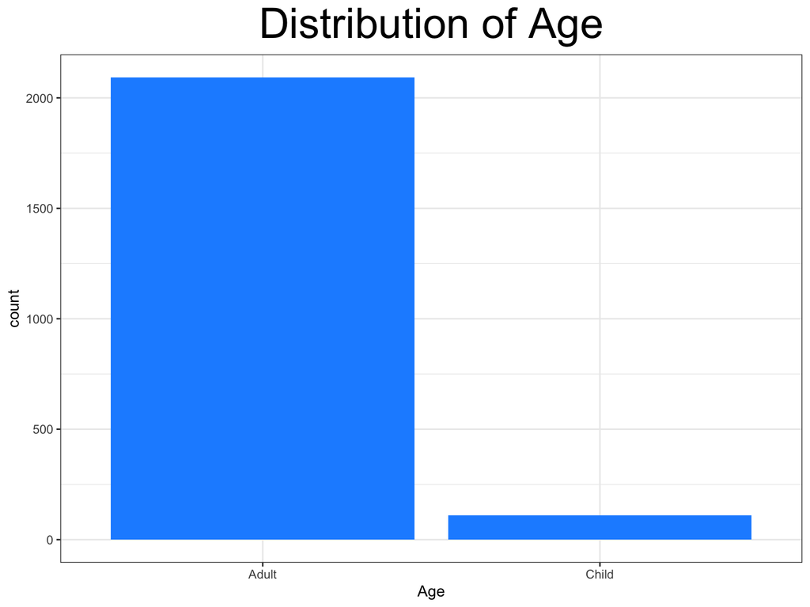

```r
ggplot(data = titanic) + geom_bar(mapping = aes(x = Age), fill="dodgerblue") +ggtitle("Distribution of Age") + theme(plot.title= element_text(size=30)) + theme(plot.title = element_text(hjust = 0.5))
```

*The Researcher is interested in understanding the distribution of the Age variable and thus, both a table and bar plot are displayed above in order for the researcher to get a better sense of the distribution.

# Titanic Sex

```r
table(titanic$Sex)
```

```
##
## Female   Male
##    470   1731
```

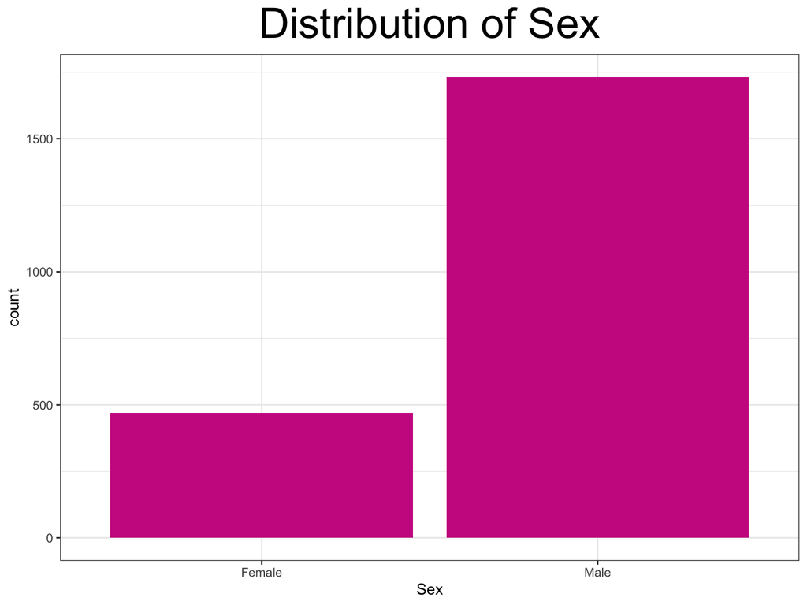

```r
ggplot(data = titanic) + geom_bar(mapping = aes(x = Sex), fill= "maroon3") +ggtitle("Distribution of Sex") + theme(plot.title= element_text(size=30)) + theme(plot.title = element_text(hjust = 0.5))
```

*The Researcher is interested in understanding the distribution of the Sex variable and thus, both a table and bar plot are displayed above in order for the researcher to get a better sense of the distribution

# Analysis: Relationships between Sex, Class, and Age

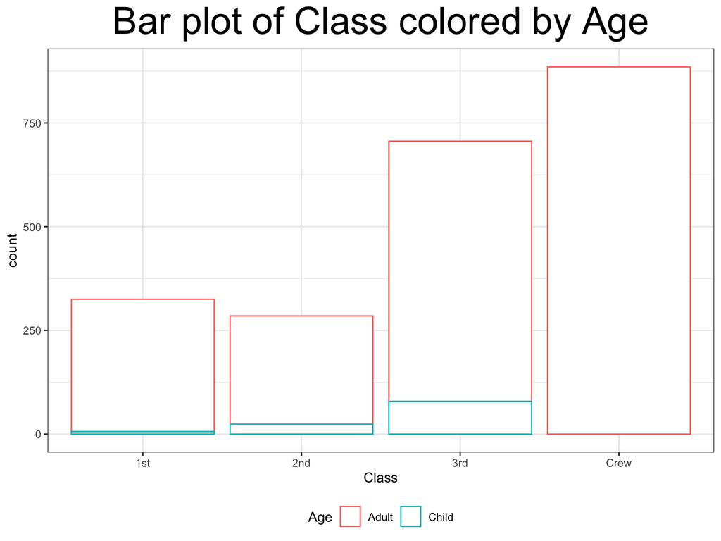

```r
ggplot(data = titanic) + geom_bar(mapping = aes(x = Class, color=Age), fill="white") +ggtitle("Bar plot of Class colored by Age") + theme(plot.title= element_text(size=30)) + theme(plot.title = element_text(hjust = 0.5))
```

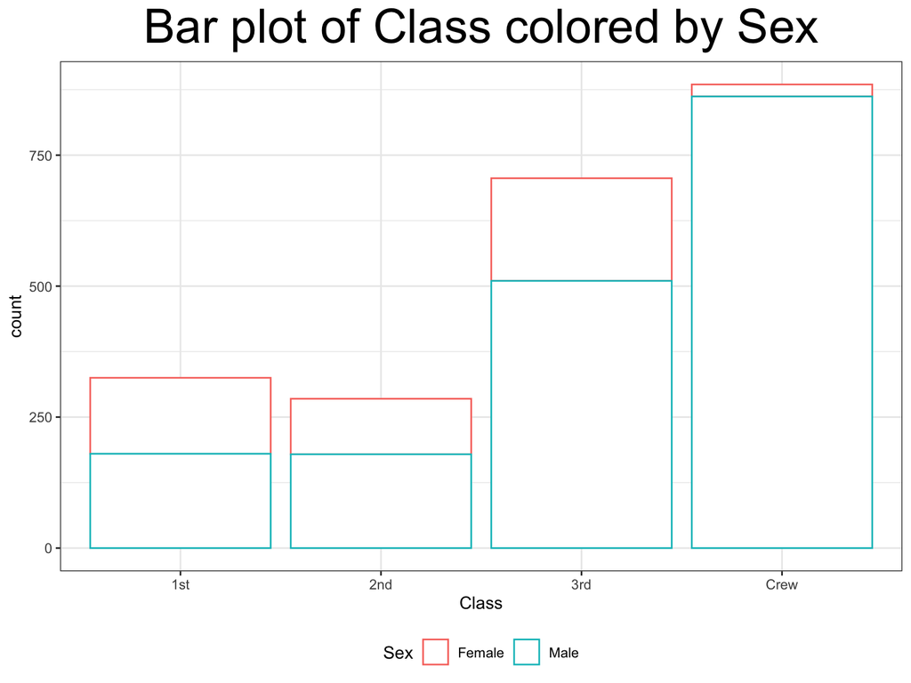

```r
ggplot(data = titanic) + geom_bar(mapping = aes(x = Class, color=Sex), fill="white") +ggtitle("Bar plot of Class colored by Sex") + theme(plot.title= element_text(size=30)) + theme(plot.title = element_text(hjust = 0.5))
```

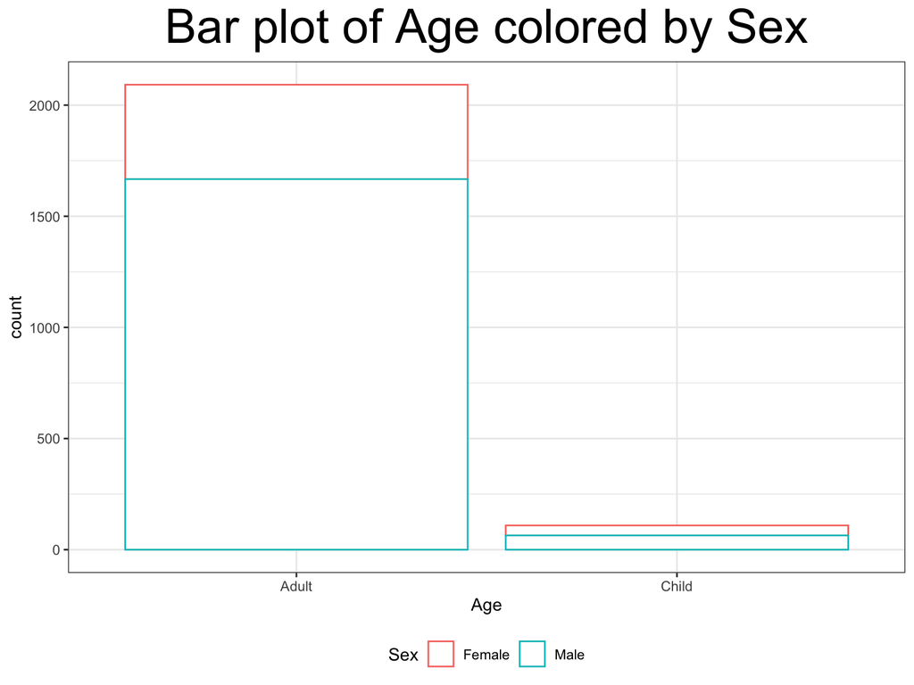

```r
ggplot(data = titanic) + geom_bar(mapping = aes(x = Age, color=Sex), fill="white") +ggtitle("Bar plot of Age colored by Sex") + theme(plot.title= element_text(size=30)) + theme(plot.title = element_text(hjust = 0.5))
```

** Two of the three bar plots above map Class and then are colored by one of the variables, Age or Sex. Class was chosen as the mapping variable since it is broken up into four categories and thus the relatinoships between variables are more clearly seen as opposed to mapping Age or Sex and coloring by Class.